# Activity: Bird Species

Allison Rachor

6/23/23

# Set Up

```r
# Load `tidyverse` and `dcData` packages
library(tidyverse)
library(dcData)



# Load the `OrdwayBirds` data set into your RStudio environment from the `dcData` package
data("OrdwayBirds")



# Show a few commands used to inspect the data set a few different ways
head(OrdwayBirds)
```

|  | bogus | Timestamp | Year | Day | Month | CaptureTime | SpeciesName | Sex | Age | BandNumber | TrapID | Weather | BandingReport | RecaptureYN | RecaptureMonth | RecaptureDay | Condition | Release | Comments | DataEntryPerson | Weight | WingChord | Temperature | RecaptureOriginal | RecapturePrevious | TailLength |
| --- | --- | --- | --- | --- | --- | --- | --- | --- | --- | --- | --- | --- | --- | --- | --- | --- | --- | --- | --- | --- | --- | --- | --- | --- | --- | --- |
| 3 | . | 4/14/2010 13:20:56 | 1972 | 16 | 7 | 7:00:00 | Song Sparrow | U | AHY (After Hatch Year) | 107-151187 | warbler | none | check mark in record | no check | none | none | none | none | none | Jerald Dosch |  |  |  |  |  |  |
| 4 | . |  |  |  |  |  |  |  |  |  |  |  |  |  |  |  |  |  |  | Caitlin Baker |  |  |  |  |  |  |
| 5 | . | 5/13/2010 16:00:30 | 1972 | 16 | 7 | 7:00:00 | Song Sparrow | U | AHY (After Hatch Year) | 107-151187 | Warbler | none | check mark in record | no check | none | none | none | none | none | Caitlin Baker |  |  |  |  |  |  |
| 6 | . | 5/13/2010 16:02:15 | 1972 | 16 | 7 | 7:00:00 | Field Sparrow | U | AHY (After Hatch Year) | 1260-74572 | Warbler | none | no check mark in record | check or yes | 7 | 9 | none | none | none | Caitlin Baker |  |  |  |  |  |  |
| 7 | . | 5/13/2010 16:03:18 | 1972 | 16 | 7 | 7:00:00 | Field Sparrow | U | AHY (After Hatch Year) | 1260-74541 | Elevator | none | no check mark in record | check or yes | 4 | 25 | none | none | none | Caitlin Baker |  |  |  |  |  |  |
| 8 | . | 5/13/2010 16:04:23 | 1972 | 16 | 7 | 7:00:00 | Song Sparrow | U | AHY (After Hatch Year) | 107-151188 | Elevator | none | check mark in record | no check | none | none | none | none | none | Caitlin Baker |  |  |  |  |  |  |

```r
tail(OrdwayBirds)
```

|  | bogus | Timestamp | Year | Day | Month | CaptureTime | SpeciesName | Sex | Age | BandNumber | TrapID | Weather | BandingReport | RecaptureYN | RecaptureMonth | RecaptureDay | Condition | Release | Comments | DataEntryPerson | Weight | WingChord | Temperature | RecaptureOriginal | RecapturePrevious | TailLength |
| --- | --- | --- | --- | --- | --- | --- | --- | --- | --- | --- | --- | --- | --- | --- | --- | --- | --- | --- | --- | --- | --- | --- | --- | --- | --- | --- |
| 15826 | . | 4/30/2012 13:57:19 | 1985 | 19 | 3 | 9:00:00 | Slate-colored Junco | F | AHY (After Hatch Year) | 1370-99513 | /1 | clear; calm | check mark in record | no check | none | none | none | none | U? | Mary Catherine Muñiz | 19.7 | 71 |  |  |  | 61 |
| 15827 | . | 4/30/2012 13:58:49 | 1985 | 19 | 3 | 9:00:00 | Slate-colored Junco | M | AHY (After Hatch Year) | 1370-99514 | /1 | clear; calm | check mark in record | no check | none | none | none | none | male? | Mary Catherine Muñiz | 20.9 | 79 |  |  |  | 69 |
| 15828 | . | 4/30/2012 14:01:15 | 1985 | 19 | 3 | 9:00:00 | Tree Sparrow | U | AHY (After Hatch Year) | 1670-88472 | /1 | clear; calm | check mark in record | no check | none | none | none | none | none | Mary Catherine Muñiz | 17.1 | 71 |  |  |  | 64 |
| 15829 | . | 4/30/2012 14:02:16 | 1985 | 19 | 3 | 11:00:00 | White-breasted Nuthatch | M | AHY (After Hatch Year) | 2020-45042 | /1 | clear; calm | check mark in record | no check | none | none | none | none | none | Mary Catherine Muñiz | 22.1 | 90 |  |  |  | 45 |
| 15830 | . | 4/30/2012 14:04:13 | 1985 | 26 | 3 | 7:00:00 | Slate-colored Junco | U | AHY (After Hatch Year) | 1370-99515 | T/4 | cloudy, drizzle; moderate winds | check mark in record | no check | none | none | none | none | male? R3 nail missing | Mary Catherine Muñiz | 22.2 | 76 |  |  |  | 64 |
| 15831 | . | 4/30/2012 14:06:27 | 1985 | 26 | 3 | 7:00:00 | Slate-colored Junco | U | AHY (After Hatch Year) | 1370-99516 | /1 | cloudy, drizzle; moderate winds | check mark in record | no check | none | none | none | none | U? | Mary Catherine Muñiz | 21.8 | 75 |  |  |  | 66 |

```r
summary(OrdwayBirds)
```

```
    bogus            Timestamp             Year               Day
 Length:15829       Length:15829       Length:15829       Length:15829
 Class :character   Class :character   Class :character   Class :character
 Mode  :character   Mode  :character   Mode  :character   Mode  :character
    Month           CaptureTime        SpeciesName            Sex
 Length:15829       Length:15829       Length:15829       Length:15829
 Class :character   Class :character   Class :character   Class :character
 Mode  :character   Mode  :character   Mode  :character   Mode  :character
     Age             BandNumber           TrapID            Weather
 Length:15829       Length:15829       Length:15829       Length:15829
 Class :character   Class :character   Class :character   Class :character
 Mode  :character   Mode  :character   Mode  :character   Mode  :character
 BandingReport      RecaptureYN        RecaptureMonth     RecaptureDay
 Length:15829       Length:15829       Length:15829       Length:15829
 Class :character   Class :character   Class :character   Class :character
 Mode  :character   Mode  :character   Mode  :character   Mode  :character
  Condition           Release            Comments         DataEntryPerson
 Length:15829       Length:15829       Length:15829       Length:15829
 Class :character   Class :character   Class :character   Class :character
 Mode  :character   Mode  :character   Mode  :character   Mode  :character
    Weight           WingChord         Temperature        RecaptureOriginal
 Length:15829       Length:15829       Length:15829       Length:15829
 Class :character   Class :character   Class :character   Class :character
 Mode  :character   Mode  :character   Mode  :character   Mode  :character
 RecapturePrevious   TailLength
 Length:15829       Length:15829
 Class :character   Class :character
 Mode  :character   Mode  :character
```

# Activity

When you’re finished with this activity, you will have a graph that shows what time of year various species appear at the Katherine Ordway Natural History Study Area in Inver Grove Heights, MN.

### Step 0

Before we begin, the book gives us some instructions to select a few key variables and clean up the date formatting. Use the commands given in the book, but be sure to study the functions used so you know what is happening. In this case, we select `SpeciesName`, `Month`, and `Day`. Then a `mutate()` command converts each variable to character, and then converts the resulting “character string” to a number.

```r
# Get the data table & clean up dates (see Data Computing eBook)
OrdwayBirds <-
  OrdwayBirds %>%
  select( SpeciesName, Month, Day ) %>%
  mutate( Month = as.numeric(as.character(Month)),
          Day = as.numeric(as.character(Day)))
Corrected <-
  OrdwayBirds %>%
  inner_join( OrdwaySpeciesNames ) %>%
  select( Species = SpeciesNameCleaned, Month, Day ) %>%
  na.omit()  # cleaned up the missing ones
# Inspect resulting data
head(OrdwayBirds)
```

|  | SpeciesName | Month | Day |
| --- | --- | --- | --- |
| 3 | Song Sparrow | 7 | 16 |
| 4 |  | NA | NA |
| 5 | Song Sparrow | 7 | 16 |
| 6 | Field Sparrow | 7 | 16 |
| 7 | Field Sparrow | 7 | 16 |
| 8 | Song Sparrow | 7 | 16 |

```r
head(Corrected)
```

|  | Species | Month | Day |
| --- | --- | --- | --- |
| 1 | Song Sparrow | 7 | 16 |
| 3 | Song Sparrow | 7 | 16 |
| 4 | Field Sparrow | 7 | 16 |
| 5 | Field Sparrow | 7 | 16 |
| 6 | Field Sparrow | 7 | 16 |
| 7 | Field Sparrow | 7 | 16 |

### Step 1

The textbook points out the data set OrdwaySpeciesNames, which includes a variable called SpeciesNameCleaned. Summarizing both the original data set and the clean list, there are 166 more “unique” names in the original data set due to spelling mistakes (there were 275 unique names in OrdwayBirds and 109 in OrdwaySpeciesNames.

```r
# unique species in original data (including mis-spellings)
OrdwayBirds %>%
  summarize(n_distinct(SpeciesName))
```

| n_distinct(SpeciesName) |
| --- |
| 275 |

```r
# unique species in the clean list
OrdwaySpeciesNames %>%
  summarize(n_distinct(SpeciesNameCleaned))
```

| n_distinct(SpeciesNameCleaned) |
| --- |
| 109 |

```r
NA
```

### Step 2

```r
# inspect OrdwaySpeciesNames
data("OrdwaySpeciesNames")
head(OrdwaySpeciesNames)
```

|  | SpeciesName | SpeciesNameCleaned |
| --- | --- | --- |
| 1 |  | NA |
| 2 | -lost- | NA |
| 3 | -missing- | NA |
| 4 | [Nothing, just dashes] | NA |
| 5 | 13:00:00 | NA |
| 6 | Acadian Flycatcher | Acadian Flycatcher |

```r
tail(OrdwaySpeciesNames)
```

|  | SpeciesName | SpeciesNameCleaned |
| --- | --- | --- |
| 260 | Yellow-bellied Sapsucker | Yellow-bellied Sapsucker |
| 261 | Yellow Shafted Flicker | Yellow Shafted Flicker |
| 262 | Yellow Shafted Flicker | Yellow Shafted Flicker |
| 263 | Yellow Shafted Flicker | Yellow Shafted Flicker |
| 264 | Yellow-tailed Oriole | Yellow-tailed Oriole |
| 265 | Yellowthroat | Yellowthroat |

```r
# inner join
Corrected <-
  OrdwayBirds %>%
  inner_join( OrdwaySpeciesNames ) %>%
  select( Species = SpeciesNameCleaned, Month, Day ) %>%
  na.omit()  # cleaned up the missing ones
# inspect the data after the join
head(Corrected)
```

|  | Species | Month | Day |
| --- | --- | --- | --- |
| 1 | Song Sparrow | 7 | 16 |
| 3 | Song Sparrow | 7 | 16 |
| 4 | Field Sparrow | 7 | 16 |
| 5 | Field Sparrow | 7 | 16 |
| 6 | Field Sparrow | 7 | 16 |
| 7 | Field Sparrow | 7 | 16 |

```r
summary(Corrected)
```

```
   Species              Month             Day
 Length:15144       Min.   : 1.000   Min.   :   1.00
 Class :character   1st Qu.: 5.000   1st Qu.:   8.00
 Mode  :character   Median : 7.000   Median :  15.00
                    Mean   : 7.113   Mean   :  15.55
                    3rd Qu.:10.000   3rd Qu.:  23.00
                    Max.   :25.000   Max.   :1975.00
```

### Step 3

We want to identify the top 5-6 bird species sighted at the Katherine Ordway Natural History Study Area.

The Corrected data set was used to group the species names together to allow for a total of times each species was sighted could be counted. A threshold of 700 was set so that only the top 6 sighted birds would be considered a major species in the area.

```r
# count sightings by species in descending order
Corrected %>%
  group_by(Species) %>%
  summarize(count = n()) %>%
  arrange(desc(count))
```

| Species | count |
| --- | --- |
| Slate-colored Junco | 2732 |
| Tree Swallow | 1537 |
| Black-capped Chickadee | 1327 |
| American Goldfinch | 1204 |
| Field Sparrow | 1164 |
| Lincoln's Sparrow | 790 |
| Robin | 608 |
| Catbird | 554 |
| Song Sparrow | 512 |
| House Wren | 460 |

[output cut: 98 more lines]

```r
# a hint in the text book recommends displaying the top 10 species to choose our threshold

Corrected %>%
  group_by(Species) %>%
  summarize(count = n()) %>%
  arrange(desc(count)) %>%
  head(10)
```

| Species | count |
| --- | --- |
| Slate-colored Junco | 2732 |
| Tree Swallow | 1537 |
| Black-capped Chickadee | 1327 |
| American Goldfinch | 1204 |
| Field Sparrow | 1164 |
| Lincoln's Sparrow | 790 |
| Robin | 608 |
| Catbird | 554 |
| Song Sparrow | 512 |
| House Wren | 460 |

```r
# define a sightings threshold; produce a table with only birds belonging to major species
threshold = 700

Majors <- Corrected %>%
  group_by(Species) %>%
  summarize(count = n()) %>%
  filter(count >= threshold)
head(Majors)
```

| Species | count |
| --- | --- |
| American Goldfinch | 1204 |
| Black-capped Chickadee | 1327 |
| Field Sparrow | 1164 |
| Lincoln's Sparrow | 790 |
| Slate-colored Junco | 2732 |
| Tree Swallow | 1537 |

```r
NA
NA
NA
```

### Step 4

We now want to produce a month-by-month count for each of the major species, and then construct a chart to tell the story of what time of year the various species appear.

```r
# prepare glyph-ready data table called `ByMonth`

Majors2 <- c("American Goldfinch", "Black-capped Chickadee", "Field Sparrow", "Lincoln's Sparrow", "Slate-colored Junco")

ByMonth <- Corrected %>%
  filter(Species %in% Majors2) %>%
  group_by(Species, Month) %>%
  summarize(count = sum(Month))
```

Now use the ggplot template below to generate the desired graph. (Remark you can also use esquisser or mplot to create a line chart instead of the barchart)

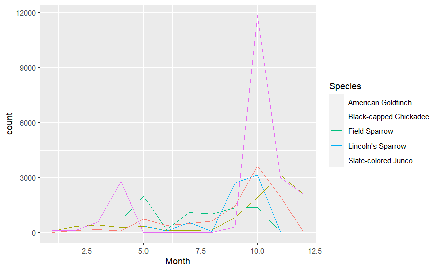

```r
# ggplot commands

ByMonth %>%
  ggplot(aes(x = Month, y = count, color = Species)) +
  geom_line()
```

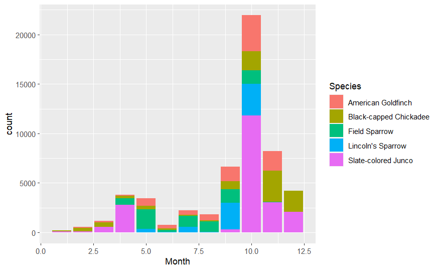

```r
ByMonth %>% ggplot(aes(x=Month,y=count ,fill=Species)) +
  geom_bar(stat='identity',position='stack', width=.9)
```

According to the graph, we can answer the questions posed:

##### 1. Which species are present year-round?

The only species seen year-round is the Black-capped Chickadee.